# Data Analysis for Thesis

Jakub Przewoski

2025-04-28

# Description

In this file I will be writing down the methodological notes for my thesis and I will also compute here my experiment.

## Experiment-setup:

I am trying to investigate whether firms can utilize greenwashing as a profitable strategy. In order to do that I want to create a measure of greenwashing by following *(Lagasio, 2024)*. Furthermore, I will utilize a natural experiment (DiD) to search for causality.

## Experiment notes:

- Use a DiD with continuous treatment to see whether greenwashing more makes you profit more
- For applying treatment, use the level of greenwashing from 2017/2018
  - The justification is that I need to assume that the treatment level was constant which implies that I should have as little time as possible between the treatment assignment and my shock
  - I have computed both the 2017 and the 2018 Greenwashing index.
- For the shock, use September 2019, as that’s when there was a lot of buzz around another IPCC report and Fridays For Future movement
  - use cumulative abnormal returns as the outcome variable
  - use sales as a secondary outcome variable

Some pictures showing google trends around specific queries around that time:

[figure not shown]

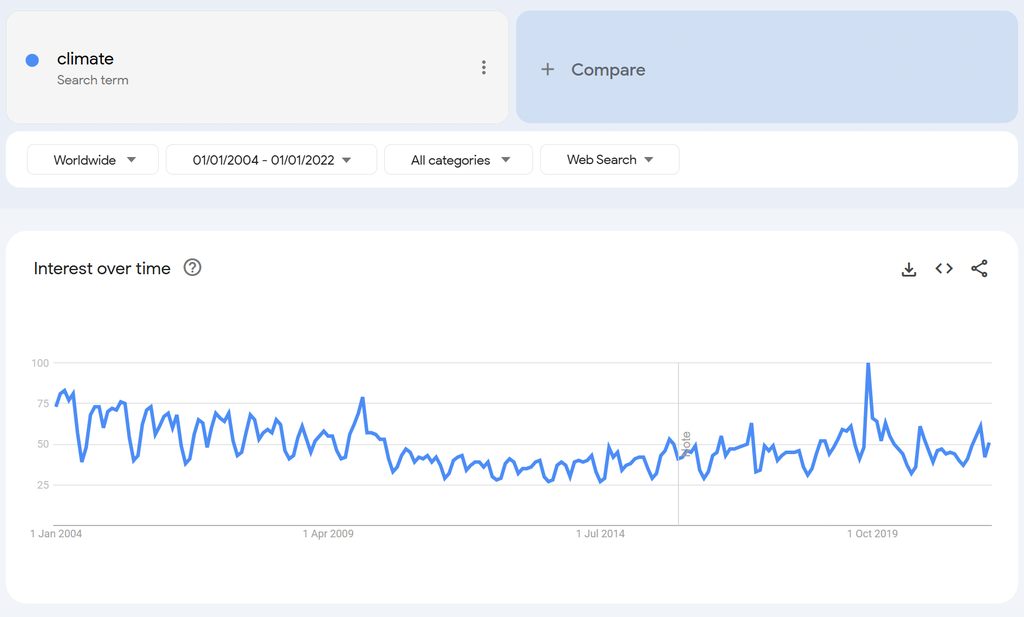

## Some links:

- [IPPC Wikipedia Page](https://en.wikipedia.org/wiki/Intergovernmental_Panel_on_Climate_Change)
- [6th IPCC Assessment](https://en.wikipedia.org/wiki/IPCC_Sixth_Assessment_Report)
- [IPCC Special Report from 2019](https://en.wikipedia.org/wiki/Special_Report_on_Climate_Change_and_Land)
- [Fridays For Future movement Wiki](https://en.wikipedia.org/wiki/Fridays_for_Future)
- [List of school climate strikes](https://en.wikipedia.org/wiki/List_of_school_climate_strikes)

# Code

## Loading libraries

```r
library(httpgd)
library(tidyverse)
library(data.table)
library(ggplot2)
library(fixest)
library(stargazer)
library(readxl)
library(stringr)
library(grid)
library(gridExtra)
library(zoo)
library(stargazer)
```

## User-defined functions

```r
# function for making my own event study plots
eve_by_t <- function(object, t_group, event_date, daily = FALSE, qtr = FALSE) {
    # x axis data
    x_axis_data <- unique(as.numeric(str_extract(rownames(object$coeftable), "(?<=TimeTo_T::).*")))
    dates <- event_date + x_axis_data # nolint: brace_linter.

    if (daily) {
        # proccess if data is daily with weekends included
        ref <- -1

    } else if (qtr) {
        # process if data is not daily and doesn't have gaps
        correct_time <- seq(min(x_axis_data), max(x_axis_data), length = (length(x_axis_data) + 1))
        ref <- correct_time[!(correct_time %in% x_axis_data)]
    } else {
        stop("Either daily of qtrly frequency must be chosen!")
    }

    # make values
    estimates <- c(as.numeric(object$coeftable[startsWith(rownames(object$coeftable), t_group), "Estimate"]))
    ci_h <- confint(object)[startsWith(rownames(object$coeftable), t_group), "97.5 %"]
    ci_l <- confint(object)[startsWith(rownames(object$coeftable), t_group), "2.5 %"]
    plot_df <- cbind(dates, estimates, ci_h, ci_l)
    plot_df <- rbind(plot_df, c((event_date + ref), 0, NA, NA))
    plot_df <- as.data.frame(plot_df) %>% arrange(dates)
    if (daily) {
        plot_df$dates <- as.Date(plot_df$dates)
    } else if (qtr) {
        plot_df$dates <- as.yearqtr(plot_df$dates)
        plot_df$dates <- as.character(plot_df$dates)
    }


    # make plot
    p <- ggplot(data = as.data.frame(plot_df)) +
        geom_hline(yintercept = 0, linetype = "dashed", color = "grey50") +
        # geom_vline(xintercept = ref, linetype = "dashed", color = "grey50") +
        geom_errorbar(aes(x = dates, ymin = ci_l, ymax = ci_h),
                      width = 0, color = "black") +
        geom_point(aes(x = dates, y = estimates),
                   size = 2, color = "black", shape = 19) +
        {if (daily) {
            scale_x_date(date_breaks = "3 days", date_labels = "%b %d")
        } else if (qtr) {
            # scale_x_discrete(breaks = dates)
        }} +
        theme_bw(base_size = 12) +
        theme(
            text = element_text(family = "Times"),
            axis.text = element_text(size = 13),
            axis.text.x = element_text(angle = 45, hjust = 1),
            axis.title.x = element_blank(),
            panel.grid.minor = element_blank(),
            panel.grid.major = element_line(color = "grey95"),
            axis.title = element_text(size = 16),
            plot.margin = unit(c(0.5, 0.5, 0.5, 0.5), "cm")
        ) +
        labs(
            y = "Estimate \\ 95% CI"
        )

    p
}

get_acrt <- function(feols_obj){
coefs <- as.data.frame(feols_obj$coeftable)
coefs$doses <- unique(as.numeric(str_extract(rownames(feols_obj$coeftable), "(?<=T_cont::)\\d")))
coefs$ACRT <- NA
coefs$ACRT_se <- NA
coefs$ACRT_se <- NA
coefs$ACRT_t.val <- NA
coefs$ACRT_p.val <- NA
dof <- feols_obj$fixef_sizes[1] - 1

for(i in c(2:nrow(coefs))){
    est_diff <- coefs$Estimate[i] - coefs$Estimate[(i - 1)]
    vcov_mat <- vcov(feols_obj)
    varr_diff <- vcov_mat[i, i] + vcov_mat[(i - 1), (i - 1)] - (2 * vcov_mat[i, (i - 1)])
    coefs$ACRT[i] <- est_diff
    coefs$ACRT_se[i]  <- sqrt(varr_diff)
    coefs$ACRT_t.val[i] <- (coefs$ACRT[i] / coefs$ACRT_se[i])
    coefs$ACRT_p.val[i] <- 2 * pt(abs(coefs$ACRT_t.val[i]), df = dof, lower.tail = FALSE)

}

coefs %>% select(ACRT, ACRT_se, ACRT_t.val, ACRT_p.val) %>% rename('Std. Error' = ACRT_se, 't value' = ACRT_t.val, 'Pr(>|t|)' = ACRT_p.val)
}
```

## Trends in articles data

[output not shown]

[output cut: 37 more lines]

[output not shown]

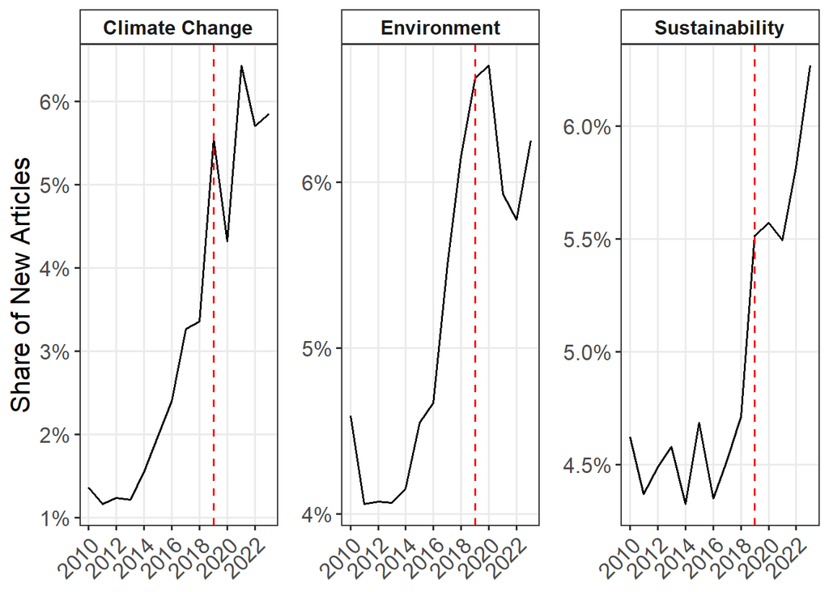

```r
trends <- read_excel("data/nyt_query.xlsx")

trends <- trends %>%
    group_by(Query) %>%
    mutate(new_art = num - lag(num)) %>%
    ungroup() %>%
    mutate(Date = as.Date(trends$Date))  %>%
    filter(Date > as.Date("2010-01-01"))


# making shares as david requested
trends_total <- trends %>%
    filter(Query == "Total") %>%
    select(Year, new_art) %>%
    rename("new_art_total" = new_art)

trends <- trends %>%
    merge(trends_total, by = "Year", all.x = TRUE) %>%
    filter(Query != "Total") %>%
    mutate(num_share = (new_art / new_art_total))


ggplot(data = trends) +
    geom_line(aes(x = Year, y = num_share), linewidth = 0.7) +
    facet_wrap(~Query, scales = "free_y", ncol = 3) +
    scale_x_continuous(breaks = seq(2010, 2023, 2)) +
    scale_y_continuous(labels = scales::percent) +
    geom_vline(aes(xintercept = 2019),
               color = "red", linetype = "dashed", size = 0.7) +
    theme_bw(base_size = 12) +
    theme(
        text = element_text(family = "Times"),
        axis.text = element_text(size = 13),
        axis.text.x = element_text(angle = 45, hjust = 1),
        axis.title = element_text(size = 16),
        axis.title.x = element_blank(),
        panel.grid.minor = element_blank(),
        panel.spacing = unit(1, "lines"),
        # legend.position = "none",
        strip.text = element_text(face = "bold", size = 12),
        strip.background = element_rect(fill = "white"),
        plot.title = element_text(size = 14, hjust = 0),
        plot.subtitle = element_text(size = 12, hjust = 0),
        plot.caption = element_text(size = 10, hjust = 0, face = "italic")
    ) +
    scale_color_grey(start = 0.2, end = 0.8) +
    labs(
        # title = "Growth in New York Times Coverage by Topic",
        # subtitle = "Number of new articles published per year (2010-2023)",
        x = "Year",
        y = "Share of New Articles",
        # caption = "Source: New York Times"
    )
```

```r
ggsave("images/output/nyt_articles.pdf", height=5.5, width=11)
```

## Google trends data

[output not shown]

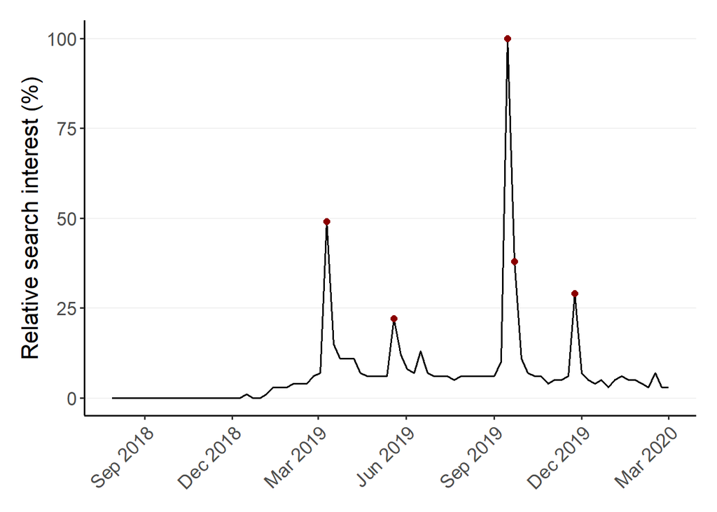

```r
fff_google <- read.csv("data/FFF_googletrends.csv", skip = 2,
                       colClasses = c("Date", "character"),
                       col.names = c("week", "value")) %>%
    mutate(
        value = ifelse(value == "<1", 1, value),
        value = as.integer(value)
    )
# View(fff_google)

# Identify significant spikes in the data (top 5%)
fff_google <- fff_google %>%
    mutate(is_spike = value > quantile(value, 0.95, na.rm = TRUE))

# Create plot with academic styling
ggplot(data = fff_google) +
        geom_line(aes(x = week, y = value, group = 1), linewidth = 0.7, color = "black") +
        geom_point(data = subset(fff_google, is_spike),
                             aes(x = week, y = value),
                             color = "darkred", size = 2, shape = 19) +
        theme_classic(base_size = 12) +
        theme(
                text = element_text(family = "Times"),
                axis.text = element_text(size = 13),
                axis.text.x = element_text(angle = 45, hjust = 1),
                axis.title = element_text(size = 16),
                axis.title.x = element_blank(),
                panel.grid.major.y = element_line(color = "gray90", linewidth = 0.3),
                panel.grid.minor = element_blank(),
                plot.margin = unit(c(1, 1, 1, 1), "lines")
        ) +
        scale_x_date(date_breaks = "3 months", date_labels = "%b %Y") +
        labs(
                # x = "Time",
                y = "Relative search interest (%)"
        )
```

```r
ggsave("images/output/fff_trend.pdf", height = 5, width=10)
```

## Loading Data for Analysis

```r
company_characteristics <- read_csv("data/output/company_characteristics.csv")
greenwashing_ind_2018  <- read_csv("data/text_processing/greenwashing_ind_2018.csv")


data_abnormal_returns_d <- read_csv("data/output/data_abnormal_returns_d.csv")
data_sales  <- read_csv("data/output/data_sales.csv")
```

Adjusting the universal data (needed for all regressions)

```r
# get rid of an observation with a missing indicator and faulty outliers
greenwashing_ind_2018 <- greenwashing_ind_2018 %>%
    filter(!(NAME %in% c("Genmab A/S", "Ashland Inc.", "Fletcher Building Limited", "Ethan Allen Interiors Inc.",
                         "Equifax Inc.", "Sagicor Financial Company Ltd.", "Korn/Ferry International",
                         "Spark NZ", "Covestro AG")),
           CLIMATE_REL > 2)  %>%
    mutate(GREEN_IND_2 = NON_SPEC / CLIMATE_REL,
        T_cont = case_when(
            GREEN_IND_2 < quantile(GREEN_IND_2, prob = c(0.25)) ~ 1,
            (GREEN_IND_2 >= quantile(GREEN_IND_2, prob = c(0.25))) &
                (GREEN_IND_2 < quantile(GREEN_IND_2, prob = c(0.5))) ~ 2,
            (GREEN_IND_2 >= quantile(GREEN_IND_2, prob = c(0.5))) &
                (GREEN_IND_2 < quantile(GREEN_IND_2, prob = c(0.75))) ~ 3,
            GREEN_IND_2 >= quantile(GREEN_IND_2, prob = c(0.75)) ~ 4
        ),
        T_ = ifelse(GREEN_IND > mean(GREEN_IND), 1, 0)
    )


company_characteristics  <- company_characteristics  %>% filter(YEAR == 2018)
company_characteristics_2018 <- merge(company_characteristics, greenwashing_ind_2018,
                                      by.x = "NAME_SCRAPED", by.y = "NAME") %>%
    select(c("TYPE", "NAME", "BOURSE_NAME", "ICB_INDUSTRY_NAME", "ICB_SECTOR_NAME", "CTRY_OF_DOM_NAME",
             "CTRY_OF_INC_NAME", "EMPLOYEES", "YEAR", "GREEN_IND_2", "T_", "T_cont")) %>%
    filter(!duplicated(NAME))
```

## Descriptive statistics

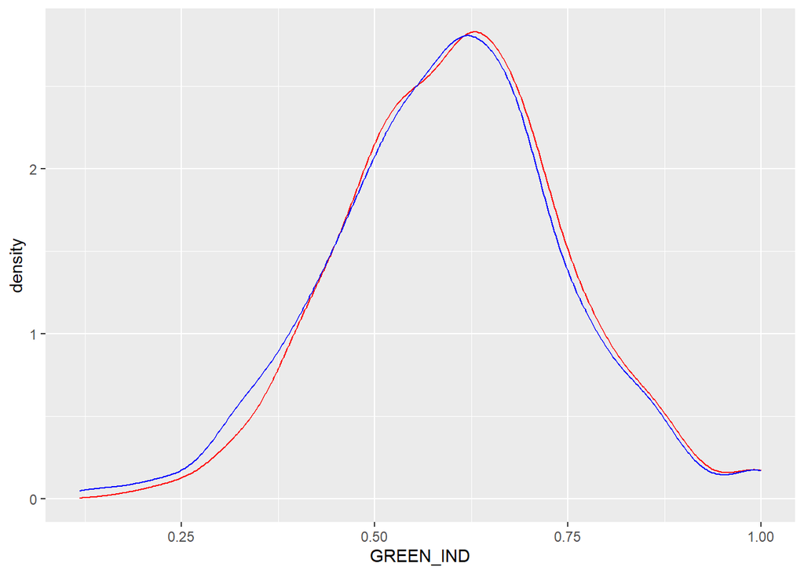

```r
ggplot(greenwashing_ind_2018) +
    geom_density(aes(x = GREEN_IND), color = "red") +
    geom_density(aes(x = GREEN_IND_2), color = "blue")
```

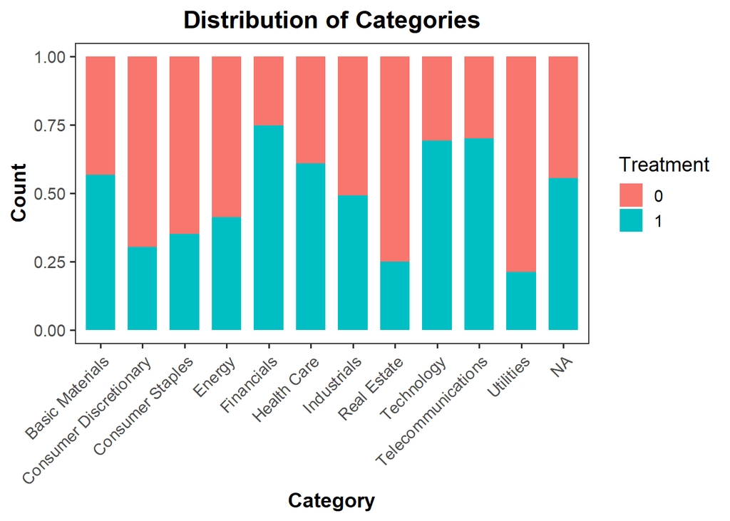

```r
ggplot(data = company_characteristics_2018,
       #    aes(x = factor(ICB_INDUSTRY_NAME))) +
       aes(x = factor(ICB_INDUSTRY_NAME), fill = factor(T_))) +
    # geom_bar(fill   = "steelblue", color  = "black", width  = 0.7) +
    geom_bar(position = "fill", width = 0.7) +
    labs(
         x     = "Category",
         y     = "Count",
         title = "Distribution of Categories",
         fill="Treatment") +
    theme_bw(base_size = 14) +
    theme(
          panel.grid.major    = element_blank(),
          panel.grid.minor    = element_blank(),
          axis.text.x         = element_text(angle = 45, hjust = 1),
          plot.title          = element_text(hjust = 0.5, face = "bold"),
          axis.title          = element_text(face = "bold"))
```

```r
# here I made some tables for the latex document (descriptive statistics)
# library(gtsummary)

# tbl_ltx = company_characteristics_2018 %>%
#     select(CTRY_OF_DOM_NAME, T_cont) %>%
#     tbl_summary(
#                 by = T_cont,
#                 statistic = list(CTRY_OF_DOM_NAME ~ "{n} ({p}%)")) %>%
#     add_overall() %>%
#     modify_header(
#                   label     = "Number of ...",
#                   all_stat_cols() ~ "{level} (N = {n})") %>%
#     modify_table_body(~.x %>% relocate(stat_0, stat_2, stat_1, .after = label))


# tbl_ltx %>%
#   as_kable(
#     format    = "latex",
#     booktabs  = TRUE
#   )

# # number of reports per year
# tbl_yrs = company_characteristics %>%
#     group_by(YEAR) %>%
#     summarize(num = n()) %>%
#     arrange(desc(num))

# as_gtsummary(tbl_yrs) %>%
#   as_kable(
#     format    = "latex",
#     booktabs  = TRUE
#   )
```

## Daily Stock data

### Merge the data

```r
# daily
reg_data_d <- merge(company_characteristics_2018, data_abnormal_returns_d, by = "NAME")  %>%
    rename("CTRY_OF_DOM_NAME" = "CTRY_OF_DOM_NAME.x") %>%
    select(-CTRY_OF_DOM_NAME.y) %>%
    arrange(NAME, DATE) %>%
    mutate(
        ABN_RET_LOG = STOCK_LOG_RETURN - NORMAL_RETURN,
        # POST_test = ifelse((DATE >= as.Date("2019-08-15")) & (DATE <= as.Date("2019-09-10'")), 1, 0),
        POST_1 = ifelse(DATE >= as.Date("2019-09-20"), 1, 0),
        POST_rb_5 = ifelse(DATE >= as.Date("2019-09-15"), 1, 0),
        POST_rb_10 = ifelse(DATE >= as.Date("2019-09-10"), 1, 0),
        DATE = as.Date(DATE),
        DATE_factor = factor(DATE),
        NAME_factor = factor(NAME),
        T_cont = as.factor(T_cont)
    )


reg_data_d <- reg_data_d  %>%
    group_by(NAME) %>%
    filter(!(is.na(ABN_RET_LOG))) %>%
    mutate(CAR = cumsum(ABN_RET_LOG)) %>%
    ungroup() %>%
    # filter(DATE > as.Date("2019-07-15"), DATE < as.Date("2019-10-10")) %>%
    filter(DATE > as.Date("2019-09-01"), DATE < as.Date("2019-10-10")) %>%
    arrange(NAME, DATE)

# View(reg_data_d)
```

### CAR Evolution per group

```r
car_graph_d  <- reg_data_d %>%
    group_by(T_cont, DATE) %>%
    summarize(mean_car = mean(CAR))
head(car_graph_d)
```

```
## # A tibble: 6 × 3
## # Groups:   T_cont [1]
##   T_cont DATE       mean_car
##   <fct>  <date>        <dbl>
## 1 1      2019-09-02  -0.0177
## 2 1      2019-09-03  -0.0218
## 3 1      2019-09-04  -0.0198
## 4 1      2019-09-05  -0.0167
## 5 1      2019-09-06  -0.0190
## 6 1      2019-09-09  -0.0116
```

[output not shown]

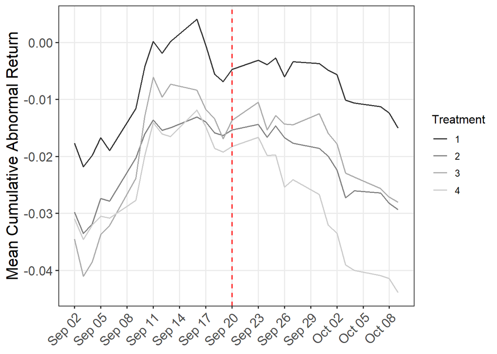

```r
ggplot(data = car_graph_d) +
    geom_line(aes(x = DATE, y = mean_car, color = as.factor(T_cont), group = T_cont), linewidth = 0.7) +
    geom_vline(aes(xintercept = as.Date("2019-09-20")),
               color = "red", linetype = "dashed", size = 0.7) +
    scale_color_grey(start = 0.2, end = 0.8, name = "Treatment") +
    scale_x_date(date_breaks = "3 days", date_labels = "%b %d") +
    theme_bw(base_size = 12) +
    theme(
        text = element_text(family = "Times"),
        axis.text = element_text(size = 13),
        axis.text.x = element_text(angle = 45, hjust = 1),
        axis.title = element_text(size = 16),
        axis.title.x = element_blank(),
        panel.grid.minor = element_blank(),
        panel.spacing = unit(1, "lines"),
        strip.text = element_text(face = "bold", size = 12),
        strip.background = element_rect(fill = "white"),
        plot.title = element_text(size = 14, face = "bold", hjust = 0)
    ) +
    labs(
        x = "Date",
        y = "Mean Cumulative Abnormal Return"
    )
```

```r
ggsave("images/output/stock_d_trend.pdf", height=6, width=8)
```

### DiD

```r
did_stock <- feols(CAR ~  i(T_cont, POST_1, ref = 1) | NAME_factor + DATE_factor,
               data = reg_data_d, cluster = ~NAME_factor)
summary(did_stock)
```

```
## OLS estimation, Dep. Var.: CAR
## Observations: 17,752
## Fixed-effects: NAME_factor: 634,  DATE_factor: 28
## Standard-errors: Clustered (NAME_factor)
##                   Estimate Std. Error   t value Pr(>|t|)
## T_cont::2:POST_1 -0.001955   0.005369 -0.364108 0.715899
## T_cont::3:POST_1  0.000818   0.005760  0.141972 0.887147
## T_cont::4:POST_1 -0.009117   0.005405 -1.686862 0.092123 .
## ---
## Signif. codes:  0 '***' 0.001 '**' 0.01 '*' 0.05 '.' 0.1 ' ' 1
## RMSE: 0.037633     Adj. R2: 0.899446
##                  Within R2: 0.002661
```

```r
# -------- estimating acrts
acrt_did_stock <- get_acrt(did_stock)
```

### DiD for robustness

```r
# ------------ 5 days before
did_stock_rb_5 <- feols(CAR ~  i(T_cont, POST_rb_5, ref = 1) | NAME_factor + DATE_factor,
               data = reg_data_d, cluster = ~ NAME_factor)
summary(did_stock_rb_5)
```

```
## OLS estimation, Dep. Var.: CAR
## Observations: 17,752
## Fixed-effects: NAME_factor: 634,  DATE_factor: 28
## Standard-errors: Clustered (NAME_factor)
##                      Estimate Std. Error   t value Pr(>|t|)
## T_cont::2:POST_rb_5 -0.001840   0.005606 -0.328183  0.74288
## T_cont::3:POST_rb_5  0.001676   0.005933  0.282571  0.77760
## T_cont::4:POST_rb_5 -0.007017   0.005590 -1.255162  0.20988
## ---
## Signif. codes:  0 '***' 0.001 '**' 0.01 '*' 0.05 '.' 0.1 ' ' 1
## RMSE: 0.037651     Adj. R2: 0.899348
##                  Within R2: 0.001691
```

```r
# ------------ 10 days before
did_stock_rb_10 <- feols(CAR ~  i(T_cont, POST_rb_10, ref = 1) | NAME_factor + DATE_factor,
               data = reg_data_d, cluster = ~ NAME_factor)
summary(did_stock_rb_10)
```

```
## OLS estimation, Dep. Var.: CAR
## Observations: 17,752
## Fixed-effects: NAME_factor: 634,  DATE_factor: 28
## Standard-errors: Clustered (NAME_factor)
##                       Estimate Std. Error   t value Pr(>|t|)
## T_cont::2:POST_rb_10 -0.002969   0.007111 -0.417510  0.67645
## T_cont::3:POST_rb_10  0.005785   0.007261  0.796647  0.42595
## T_cont::4:POST_rb_10 -0.006682   0.006939 -0.962947  0.33594
## ---
## Signif. codes:  0 '***' 0.001 '**' 0.01 '*' 0.05 '.' 0.1 ' ' 1
## RMSE: 0.037637     Adj. R2: 0.899421
##                  Within R2: 0.002415
```

### Event study regression

```r
event_date <- as.Date("2019-09-20")

reg_data_d_eve <- reg_data_d  %>%
    mutate(
        TimeTo_T = as.factor(difftime(reg_data_d$DATE, event_date, units = "days"))
    )


es_twfe <- feols(CAR ~ i(T_cont, TimeTo_T, ref = 1, ref2 = -1) | DATE_factor + NAME_factor,
                 cluster = ~NAME_factor, data = reg_data_d_eve)

summary(es_twfe)
```

```
## OLS estimation, Dep. Var.: CAR
## Observations: 17,752
## Fixed-effects: DATE_factor: 28,  NAME_factor: 634
## Standard-errors: Clustered (NAME_factor)
##                          Estimate Std. Error   t value  Pr(>|t|)
## T_cont::2:TimeTo_T::-18 -0.002659   0.007864 -0.338147 0.7353643
## T_cont::2:TimeTo_T::-17 -0.002260   0.008303 -0.272227 0.7855360
## T_cont::2:TimeTo_T::-16 -0.002608   0.007837 -0.332813 0.7393859
## T_cont::2:TimeTo_T::-15 -0.001215   0.006360 -0.191024 0.8485682
## T_cont::2:TimeTo_T::-14  0.000544   0.005932  0.091664 0.9269941
## T_cont::2:TimeTo_T::-11  0.000760   0.004450  0.170738 0.8644843
## T_cont::2:TimeTo_T::-10 -0.002329   0.003856 -0.603871 0.5461455
## T_cont::2:TimeTo_T::-9  -0.004370   0.003648 -1.198007 0.2313625
## T_cont::2:TimeTo_T::-8  -0.004065   0.003499 -1.161657 0.2458127
## T_cont::2:TimeTo_T::-7  -0.005696   0.003258 -1.748381 0.0808829 .
## T_cont::2:TimeTo_T::-4  -0.007672   0.003005 -2.552830 0.0109186 *
## T_cont::2:TimeTo_T::-3  -0.003964   0.001975 -2.007492 0.0451218 *
## T_cont::2:TimeTo_T::-2  -0.000797   0.001372 -0.581137 0.5613552
## T_cont::2:TimeTo_T::0   -0.001132   0.001922 -0.589306 0.5558660
## T_cont::2:TimeTo_T::3   -0.001792   0.002685 -0.667492 0.5047012
## T_cont::2:TimeTo_T::4   -0.003295   0.003343 -0.985772 0.3246217
## T_cont::2:TimeTo_T::5   -0.002433   0.003389 -0.717887 0.4730921
## T_cont::2:TimeTo_T::6   -0.001247   0.004164 -0.299553 0.7646168
## T_cont::2:TimeTo_T::7   -0.004859   0.004647 -1.045642 0.2961252
## T_cont::2:TimeTo_T::10  -0.005446   0.004697 -1.159579 0.2466575
## T_cont::2:TimeTo_T::11  -0.005629   0.005121 -1.099286 0.2720614
## T_cont::2:TimeTo_T::12  -0.007296   0.005161 -1.413799 0.1579125
## T_cont::2:TimeTo_T::13  -0.007738   0.005003 -1.546602 0.1224590
## T_cont::2:TimeTo_T::14  -0.005951   0.005199 -1.144542 0.2528314
## T_cont::2:TimeTo_T::17  -0.005684   0.005443 -1.044309 0.2967410
## T_cont::2:TimeTo_T::18  -0.006345   0.005482 -1.157524 0.2474951
## T_cont::2:TimeTo_T::19  -0.004852   0.005706 -0.850306 0.3954767
## T_cont::3:TimeTo_T::-18 -0.006746   0.007794 -0.865614 0.3870299
## T_cont::3:TimeTo_T::-17 -0.009146   0.008232 -1.110969 0.2670033
## T_cont::3:TimeTo_T::-16 -0.008626   0.007835 -1.100986 0.2713211
## T_cont::3:TimeTo_T::-15 -0.006977   0.006529 -1.068673 0.2856243
## T_cont::3:TimeTo_T::-14 -0.003137   0.006153 -0.509847 0.6103364
## T_cont::3:TimeTo_T::-11 -0.002195   0.005014 -0.437689 0.6617607
## T_cont::3:TimeTo_T::-10  0.001424   0.004596  0.309842 0.7567829
## T_cont::3:TimeTo_T::-9   0.003791   0.004490  0.844304 0.3988185
```

[output cut: 35 more lines]

```
## T_cont::4:TimeTo_T::5   -0.004652   0.003490 -1.332688 0.1831137
## T_cont::4:TimeTo_T::6   -0.006997   0.004185 -1.671794 0.0950591 .
## T_cont::4:TimeTo_T::7   -0.008347   0.004499 -1.855407 0.0640028 .
## T_cont::4:TimeTo_T::10  -0.010580   0.004760 -2.222593 0.0265958 *
## T_cont::4:TimeTo_T::11  -0.014810   0.005082 -2.914084 0.0036933 **
## T_cont::4:TimeTo_T::12  -0.015421   0.005328 -2.894290 0.0039310 **
## T_cont::4:TimeTo_T::13  -0.016535   0.005237 -3.157154 0.0016689 **
## T_cont::4:TimeTo_T::14  -0.016990   0.005594 -3.036859 0.0024889 **
## T_cont::4:TimeTo_T::17  -0.017240   0.005817 -2.963418 0.0031567 **
## T_cont::4:TimeTo_T::18  -0.016627   0.006006 -2.768516 0.0057961 **
## T_cont::4:TimeTo_T::19  -0.016451   0.006382 -2.577617 0.0101735 *
## ---
## Signif. codes:  0 '***' 0.001 '**' 0.01 '*' 0.05 '.' 0.1 ' ' 1
## RMSE: 0.037563     Adj. R2: 0.899361
##                  Within R2: 0.00638
```

```r
# making the event study plots
stock_price_eve_2 <- eve_by_t(es_twfe, "T_cont::2", event_date = event_date, daily = TRUE)
stock_price_eve_3 <- eve_by_t(es_twfe, "T_cont::3", event_date = event_date, daily = TRUE)
stock_price_eve_4 <- eve_by_t(es_twfe, "T_cont::4", event_date = event_date, daily = TRUE)

ggsave("images/output/stock_price_eve_2.pdf", stock_price_eve_2, height = 4, width = 8)
ggsave("images/output/stock_price_eve_3.pdf", stock_price_eve_3, height = 4, width = 8)
ggsave("images/output/stock_price_eve_4.pdf", stock_price_eve_4, height = 4, width = 8)
```

## Sales data

### Merge data

```r
data_sales  <- data_sales  %>%
    filter(DATE != "2010 Q1")

# View(data_sales)

reg_data_sales <- merge(company_characteristics_2018, data_sales, by = "TYPE") %>%
    arrange(NAME.y, DATE)  %>%
    select(-YEAR.x, -YEAR.y, -QUARTER, -NAME.x)  %>%
    rename(NAME = NAME.y)  %>%
    group_by(NAME) %>%
    mutate(LOG_SALES_DIFF_4 = LOG_SALES_DIFF - lag(LOG_SALES_DIFF, 4))  %>%
    ungroup() %>%
    mutate(
        POST_1 = ifelse(DATE >= "2019 Q3", 1, 0),
        DATE_factor = factor(DATE),
        NAME_factor = factor(NAME),
        T_cont = as.factor(T_cont)
    )  %>%
    filter(DATE > "2018 Q4", DATE < "2020 Q2")

# View(reg_data_sales)
```

```r
trend_graph_sales  <- reg_data_sales %>%
    group_by(T_cont, DATE) %>%
    summarize(mean_sales = mean(SALES),
              mean_sales_diff = mean(LOG_SALES_DIFF_4))
head(trend_graph_sales)
```

```
## # A tibble: 6 × 4
## # Groups:   T_cont [2]
##   T_cont DATE    mean_sales mean_sales_diff
##   <fct>  <chr>        <dbl>           <dbl>
## 1 1      2019 Q1   7194862.        -0.0260
## 2 1      2019 Q2   7543295.         0.00612
## 3 1      2019 Q3   7555413.        -0.0218
## 4 1      2019 Q4   8003293.        -0.00202
## 5 1      2020 Q1   7032178.        -0.0421
## 6 2      2019 Q1  33551361.        -0.00536
```

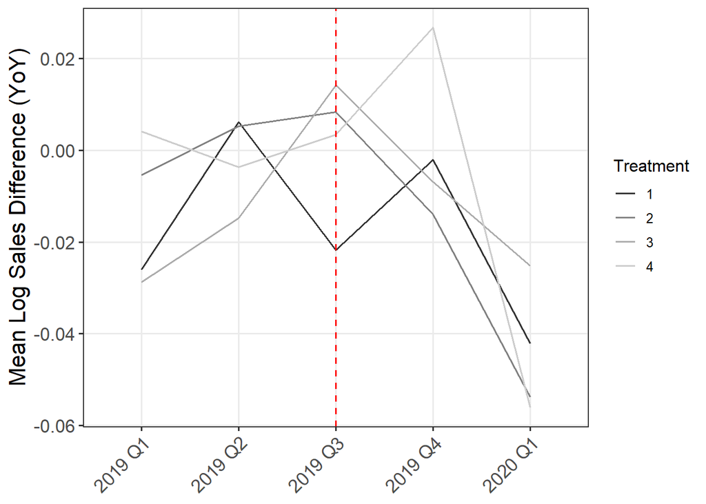

```r
# Mean sales difference by treatment group
ggplot(data = trend_graph_sales) +
    geom_line(aes(x = DATE, y = mean_sales_diff, color = as.factor(T_cont), group = T_cont), linewidth = 0.7) +
    geom_vline(aes(xintercept = "2019 Q3"),
               color = "red", linetype = "dashed", size = 0.7) +
    scale_color_grey(start = 0.2, end = 0.8, name = "Treatment") +
    theme_bw(base_size = 12) +
    theme(
        text = element_text(family = "Times"),
        axis.text = element_text(size = 13),
        axis.text.x = element_text(angle = 45, hjust = 1),
        axis.title = element_text(size = 16),
        axis.title.x = element_blank(),
        panel.grid.minor = element_blank(),
        panel.spacing = unit(1, "lines"),
        strip.text = element_text(face = "bold", size = 12),
        strip.background = element_rect(fill = "white"),
        plot.title = element_text(size = 14, face = "bold", hjust = 0)
    ) +
    labs(
        x = "Quarter",
        y = "Mean Log Sales Difference (YoY)"
    )
```

```r
ggsave("images/output/sales_trend.pdf", height=6, width=8)
```

### DiD on sales data

```r
did_sales <- feols(LOG_SALES_DIFF_4 ~ i(T_cont, POST_1, ref = 1) | NAME_factor + DATE_factor,
               data = reg_data_sales, cluster = ~ NAME_factor)
summary(did_sales)
```

```
## OLS estimation, Dep. Var.: LOG_SALES_DIFF_4
## Observations: 2,515
## Fixed-effects: NAME_factor: 503,  DATE_factor: 5
## Standard-errors: Clustered (NAME_factor)
##                   Estimate Std. Error   t value Pr(>|t|)
## T_cont::2:POST_1 -0.007723   0.015028 -0.513922 0.607533
## T_cont::3:POST_1  0.027890   0.015823  1.762586 0.078579 .
## T_cont::4:POST_1  0.003189   0.016048  0.198728 0.842556
## ---
## Signif. codes:  0 '***' 0.001 '**' 0.01 '*' 0.05 '.' 0.1 ' ' 1
## RMSE: 0.154238     Adj. R2: -0.130431
##                  Within R2:  0.00185
```

```r
# -------- estimating acrts
acrt_did_sales <- get_acrt(did_sales)
```

### Event Study - sales

```r
event_Q <- as.yearqtr("2019 Q3") # nolint

reg_data_eve <- reg_data_sales %>%
    mutate(
        # convert your dates to yearqtr
        DATE_Q   = as.yearqtr(DATE),
        event_Q  = as.yearqtr(event_Q),
        # numeric difference in quarters
        TimeTo_T = as.factor(DATE_Q - event_Q)
    )

# View(reg_data_eve)
sales_eve <- feols(LOG_SALES_DIFF_4 ~ i(T_cont, TimeTo_T, ref = 1, ref2=-0.25) | DATE_factor + NAME_factor,
                   cluster = ~NAME_factor, data = reg_data_eve)
summary(sales_eve)
```

```
## OLS estimation, Dep. Var.: LOG_SALES_DIFF_4
## Observations: 2,515
## Fixed-effects: DATE_factor: 5,  NAME_factor: 503
## Standard-errors: Clustered (NAME_factor)
##                           Estimate Std. Error   t value Pr(>|t|)
## T_cont::2:TimeTo_T::-0.5  0.021517   0.025833  0.832937 0.405276
## T_cont::2:TimeTo_T::0     0.031012   0.025375  1.222140 0.222228
## T_cont::2:TimeTo_T::0.25 -0.011072   0.024425 -0.453329 0.650508
## T_cont::2:TimeTo_T::0.5  -0.010834   0.030118 -0.359707 0.719218
## T_cont::3:TimeTo_T::-0.5  0.018109   0.033055  0.547843 0.584044
## T_cont::3:TimeTo_T::0     0.056916   0.023058  2.468402 0.013904 *
## T_cont::3:TimeTo_T::0.25  0.016098   0.028191  0.571017 0.568244
## T_cont::3:TimeTo_T::0.5   0.037819   0.026149  1.446279 0.148723
## T_cont::4:TimeTo_T::-0.5  0.039812   0.033214  1.198656 0.231227
## T_cont::4:TimeTo_T::0     0.034962   0.022316  1.566689 0.117817
## T_cont::4:TimeTo_T::0.25  0.038587   0.026571  1.452219 0.147065
## T_cont::4:TimeTo_T::0.5  -0.004263   0.027001 -0.157879 0.874615
## ---
## Signif. codes:  0 '***' 0.001 '**' 0.01 '*' 0.05 '.' 0.1 ' ' 1
## RMSE: 0.153901     Adj. R2: -0.130568
##                  Within R2:  0.00621
```

```r
# making the plots
sales_eve_2 <- eve_by_t(sales_eve, "T_cont::2", event_Q, qtr = TRUE)
sales_eve_3 <- eve_by_t(sales_eve, "T_cont::3", event_Q, qtr = TRUE)
sales_eve_4 <- eve_by_t(sales_eve, "T_cont::4", event_Q, qtr = TRUE)

ggsave("images/output/sales_eve_2.pdf", sales_eve_2, height = 4, width = 8)
ggsave("images/output/sales_eve_3.pdf", sales_eve_3, height = 4, width = 8)
ggsave("images/output/sales_eve_4.pdf", sales_eve_4, height = 4, width = 8)
```

## Making summary tables for latex

```r
# main table
etable(did_stock, did_sales, style.tex = style.tex("aer"), tex = TRUE)
```

```
## \begingroup
## \centering
## \begin{tabular}{lcc}
##    \toprule
##                                      & CAR           & LOG\_SALES\_DIFF\_4\\
##                                      & (1)           & (2)\\
##    \midrule
##    POST\_1 $\times$ T\_cont $=$ 2    & -0.0020       & -0.0077\\
##                                      & (0.0054)      & (0.0150)\\
##    POST\_1 $\times$ T\_cont $=$ 3    & 0.0008        & 0.0279$^{*}$\\
##                                      & (0.0058)      & (0.0158)\\
##    POST\_1 $\times$ T\_cont $=$ 4    & -0.0091$^{*}$ & 0.0032\\
##                                      & (0.0054)      & (0.0160)\\
##     \\
##    Observations                      & 17,752        & 2,515\\
##    R$^2$                             & 0.90320       & 0.09844\\
##    Within R$^2$                      & 0.00266       & 0.00185\\
##     \\
##    NAME\_factor fixed effects        & $\checkmark$  & $\checkmark$\\
##    DATE\_factor fixed effects        & $\checkmark$  & $\checkmark$\\
##    \bottomrule
## \end{tabular}
## \par\endgroup
```

```r
# testing the no-anticipation assumption
etable(did_stock_rb_5, did_stock_rb_10, style.tex = style.tex("aer"), tex = TRUE)
```

```
## \begingroup
## \centering
## \begin{tabular}{lcc}
##    \toprule
##     & \multicolumn{2}{c}{CAR}\\
##                                            & (1)           & (2)\\
##    \midrule
##    POST\_rb\_5 $\times$ T\_cont $=$ 2      & -0.0018       &   \\
##                                            & (0.0056)      &   \\
##    POST\_rb\_5 $\times$ T\_cont $=$ 3      & 0.0017        &   \\
##                                            & (0.0059)      &   \\
##    POST\_rb\_5 $\times$ T\_cont $=$ 4      & -0.0070       &   \\
##                                            & (0.0056)      &   \\
##    POST\_rb\_10 $\times$ T\_cont $=$ 2     &               & -0.0030\\
##                                            &               & (0.0071)\\
##    POST\_rb\_10 $\times$ T\_cont $=$ 3     &               & 0.0058\\
##                                            &               & (0.0073)\\
##    POST\_rb\_10 $\times$ T\_cont $=$ 4     &               & -0.0067\\
##                                            &               & (0.0069)\\
##     \\
##    Observations                            & 17,752        & 17,752\\
##    R$^2$                                   & 0.90311       & 0.90318\\
##    Within R$^2$                            & 0.00169       & 0.00242\\
##     \\
##    NAME\_factor fixed effects              & $\checkmark$  & $\checkmark$\\
##    DATE\_factor fixed effects              & $\checkmark$  & $\checkmark$\\
##    \bottomrule
## \end{tabular}
## \par\endgroup
```

## Other

If a company makes specific claims in their reports they would probably make them in marketing - better perceived by consumers? Think about different justifications, e.g. reports look at the past years, companies make tv commercials that can include sustainability information